# Презентация по лабораторной работе №4

# Создание репозитория

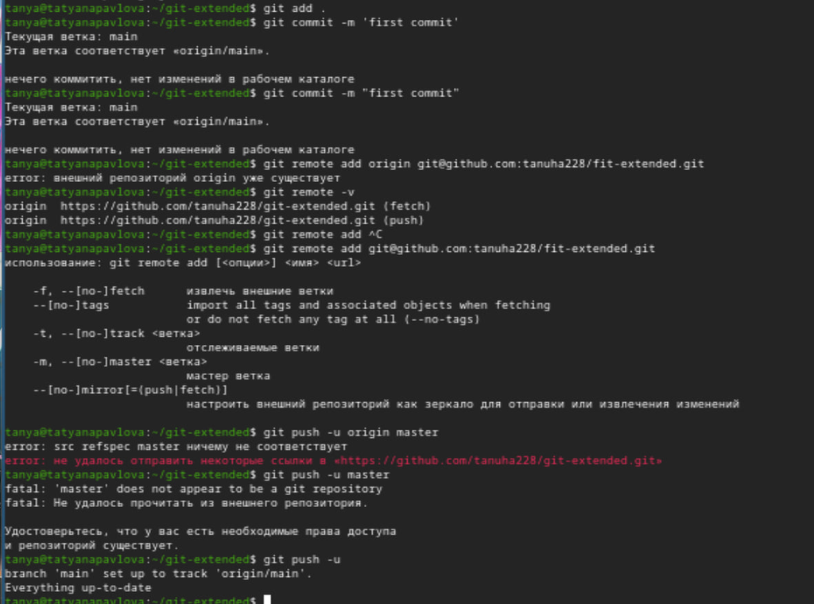

git-extended

# Добавление команды в файл

Конфигурация общепринятых коммитов. Для этого добавляю в файл package.json команду для формирования коммитов (рис. [-@fig:006]).

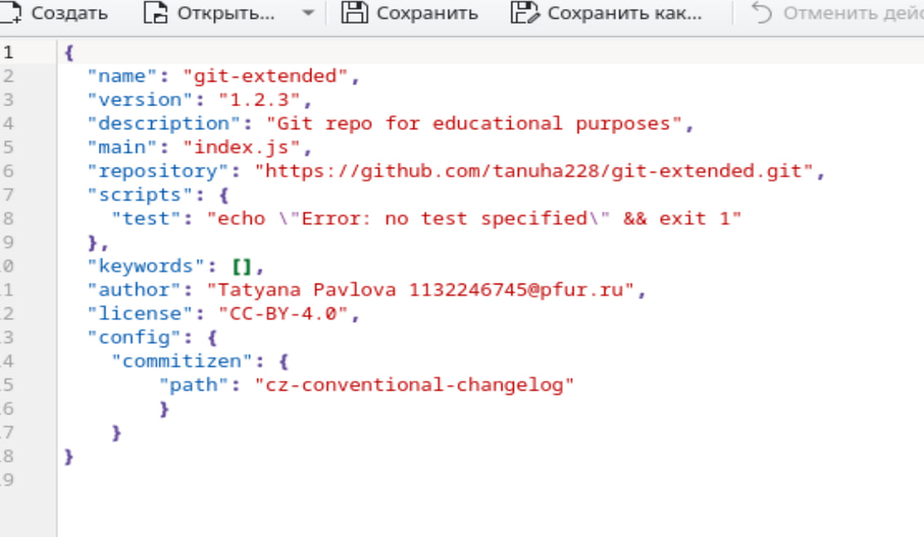

Добавление в файл

# Отправление файла на github

Добавляю файл, выполняю коммит, отправляю на github (рис. [-@fig:007]).

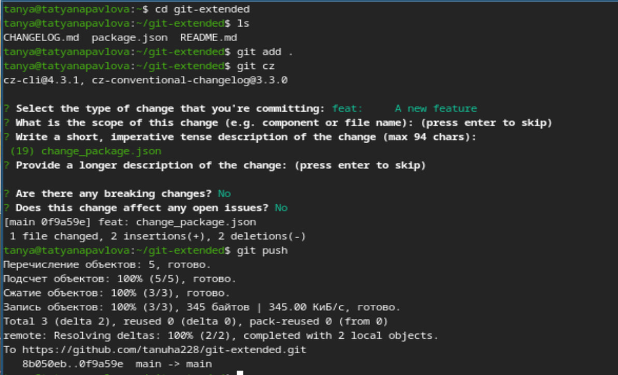

# Создаю релиз с версией 1.2.3

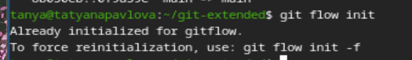

# Создаю релиз с версией 1.2.3

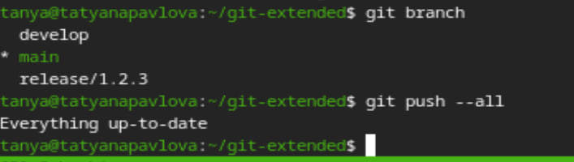

Создание релиза

# Создаю релиз с версией 1.2.3

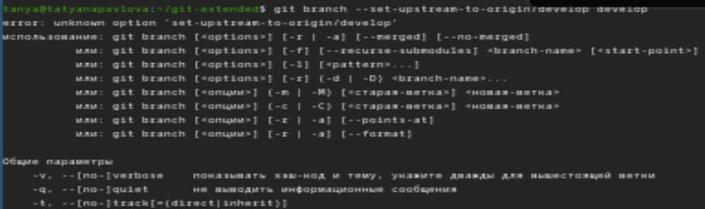

# Работа с журналом изменений

1. Создаю журнал изменений.
2. Добавляю журнал изменений в индекс.
3. Заливаю ветку в основную ветку, отправляю данные на github.
4. Создаю на нем релиз и для этого буду использовать утилиты работы с github.

# Создание ветки для новой функциональности

Создаю ветку для новой функциональности. Следующим шагом следует объеденить ветку feature_branch с develop (рис. [-@fig:011]).

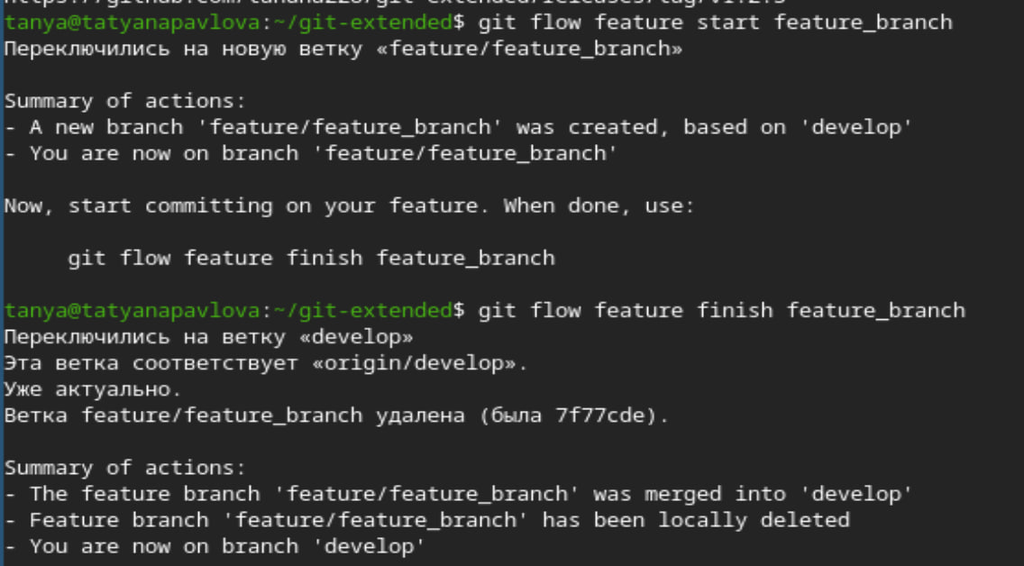

Создание ветки

# Некоторые проблемы с выполнение лабораторной работы :3

Далее оказалось, что я работала не с той версией: нужно было работать сначала с версией 1.0.0 и только потом с 1.2.3, а я сразу работала с версией 1.2.3. Но мне кажется, что в этом нет ничего особо страшного, потому что с двумя версиями нужно было производить одни и те же действия.

# Выводы

В ходе выполнения данной лабораторной работы, я получила навыки работы с репозиториями git.